# C3하지혜_빅데이터분석기초3일차

```python
import pandas as pd
import numpy as np
import matplotlib
import matplotlib.pyplot as plt
import seaborn as sns
from scipy import stats
import scipy.stats
from scipy.stats import shapiro, norm
```

```python
ds_mycars = pd.read_csv('mycars.csv')
ds_mycars.head()
```

|  | manufacturer | model | displacement | year | cylinder | automatic | driving | mpg | highway_mileage | fuel | class |
| --- | --- | --- | --- | --- | --- | --- | --- | --- | --- | --- | --- |
| 0 | audi | a4 | 1.8 | 1999 | 4 | auto | f | 18 | 29 | p | compact |
| 1 | audi | a4 | 1.8 | 1999 | 4 | manual | f | 21 | 29 | p | compact |
| 2 | audi | a4 | 2.0 | 2008 | 4 | manual | f | 20 | 31 | p | compact |
| 3 | audi | a4 | 2.0 | 2008 | 4 | auto | f | 21 | 30 | p | compact |
| 4 | audi | a4 | 2.8 | 1999 | 6 | auto | f | 16 | 26 | p | compact |

```python
# 210페이지 실습
df = ds_mycars[['automatic', 'mpg']]
df.groupby('automatic').describe()
```

| automatic | mpg count | mpg mean | mpg std | mpg min | mpg 25% | mpg 50% | mpg 75% | mpg max |
| --- | --- | --- | --- | --- | --- | --- | --- | --- |
| auto | 157.0 | 15.968153 | 3.848777 | 9.0 | 13.0 | 16.0 | 18.0 | 29.0 |
| manual | 77.0 | 18.675325 | 4.488118 | 9.0 | 15.0 | 18.0 | 21.0 | 35.0 |

```python
# 213페이지 실습
df = ds_mycars[['automatic', 'model']]
count = df[['automatic', 'model']].value_counts().sort_index()

cumcnt = np.cumsum(count)
percent = count / sum(count) * 100
cumpct = np.cumsum(percent)

count_data = pd.DataFrame({'Count': count, 'CumCnt': cumcnt, 'Percent': percent, 'CumPct': cumpct})
count_data.columns.name='automatic, model'
count_data
```

| automatic | automatic, model model | Count | CumCnt | Percent | CumPct |
| --- | --- | --- | --- | --- | --- |
| auto | 4runner 4wd | 4 | 4 | 1.709402 | 1.709402 |
|  | a4 | 4 | 8 | 1.709402 | 3.418803 |
|  | a4 quattro | 4 | 12 | 1.709402 | 5.128205 |
|  | a6 quattro | 3 | 15 | 1.282051 | 6.410256 |
|  | altima | 3 | 18 | 1.282051 | 7.692308 |
| ... | ... | ... | ... | ... | ... |
| manual | pathfinder 4wd | 1 | 219 | 0.427350 | 93.589744 |
|  | ram 1500 pickup 4wd | 4 | 223 | 1.709402 | 95.299145 |
|  | sonata | 3 | 226 | 1.282051 | 96.581197 |
|  | tiburon | 4 | 230 | 1.709402 | 98.290598 |
|  | toyota tacoma 4wd | 4 | 234 | 1.709402 | 100.000000 |

63 rows × 4 columns

# 정규분포

```python
# 226페이지 실습
mu = 175
sigma = 5
x = 180
prob = stats.norm.cdf(x, mu, sigma)
print("{0}cm의 비율: {1:.1f}%".format(x, (1-prob)*100))
```

```
180cm의 비율: 15.9%
```

```python
# 228페이지 실습
mu = 12
sigma = 3
x1 = 15
prob1 = stats.norm.cdf(x1, mu, sigma)
print("{0}km 이상 {1}km 이하를 달릴 확률은 {2:.1f}%에 해당함".format(9, x1, (prob1 - 0.5)*100*2))
print("{0}km 이상을 달릴 확률은 {2:.1f}%에 해당함".format(15, x1, (1-prob1)*100))
```

```
9km 이상 15km 이하를 달릴 확률은 68.3%에 해당함
15km 이상을 달릴 확률은 15.9%에 해당함
```

# t 분포

```python
# 236페이지 실습
t = 2.0
df = 100
prob = stats.t.cdf(t, df)
print("P(T<F): {:.3f}".format(prob))
```

```
P(T<F): 0.976
```

# 카이제곱 분포

```python
# 239페이지 실습
chisq = 3.0
df = 8
prob = stats.chi2.cdf(chisq, df)
print("P(X<={0}): {1:.4f}".format(chisq, prob))
```

```
P(X<=3.0): 0.0656
```

# F 분포

```python
# 243페이지 실습
f = 1.5
dfnum = 10
dfden = 100
prob = stats.f.cdf(x=f, dfn=dfnum, dfd=dfden)
print("P(X<=F): {:.3f}".format(prob))
```

```
P(X<=F): 0.850
```

# 이항분포

```python
# 250페이지 실습
n = 5
for i in range(n+1):
    prob = stats.binom.pmf(k=i, n=n, p=0.3)
    print("P(X={0}) = {1:.3f}".format(i, prob))
```

```
P(X=0) = 0.168
P(X=1) = 0.360
P(X=2) = 0.309
P(X=3) = 0.132
P(X=4) = 0.028
P(X=5) = 0.002
```

# 정규성 검정

```python
# 265페이지 실습
df = pd.read_csv("2sample_t_test.csv")
df.head()
```

|  | Mat_A | Mat_B | Total | Sub |
| --- | --- | --- | --- | --- |
| 0 | 73.4 | 68.7 | 73.4 | 1 |
| 1 | 77.0 | 71.4 | 77.0 | 1 |
| 2 | 73.7 | 69.8 | 73.7 | 1 |
| 3 | 73.3 | 75.3 | 73.3 | 1 |
| 4 | 73.1 | 71.3 | 73.1 | 1 |

```python
# NaN 값이 존재하므로 dropna를 해준다.
data1 = df['Mat_A'].dropna()
statistic, p = shapiro(data1)
print("Shapiro-Wilk Test: statistic={}, p-value={}".format(statistic, p))
```

```
Shapiro-Wilk Test: statistic=0.9062636494636536, p-value=0.2562994360923767
```

-> Mat_A의 p-value가 0.05보다 크므로 정규이다.

```python
# NaN 값이 존재하므로 dropna를 해준다.
data2 = df['Mat_B'].dropna()
statistic, p = shapiro(data2)
print("Shapiro-Wilk Test: statistic={}, p-value={}".format(statistic, p))
```

```
Shapiro-Wilk Test: statistic=0.9729753732681274, p-value=0.9169777035713196
```

-> Mat_B의 p-value가 0.05보다 크므로 정규이다.

# 구간추정

```python
# 268페이지 실습
df = pd.DataFrame({"sample": [18,18,20,21,20,23,19,18,17,21,22,20,20,21,20,19,19,18,17,19]})
lower, upper = stats.norm.interval(0.95, loc = np.mean(df), scale=3.8/np.sqrt(20))
print("신뢰구간: ({0}, {1})".format(lower.round(2), upper.round(2)))
```

```
신뢰구간: ([17.83], [21.17])
```

```python
# 271페이지 실습
df = pd.DataFrame({"sample": [73,71,74,69,70,73,70,68,75,72,70,72,73,70,70,72,71,70,75,72]})
lower, upper = stats.t.interval(0.95, len(df)-1, loc = np.mean(df), scale=scipy.stats.sem(df))
print("신뢰구간: ({0}, {1})".format(lower.round(2), upper.round(2)))
```

```
신뢰구간: ([70.6], [72.4])
```

# 가설검정

```
statistic=0.8473219275474548, p-value=0.053975414484739304
1-Sample t-test
t 통계량: [3.379]
p-value: [0.008]
```

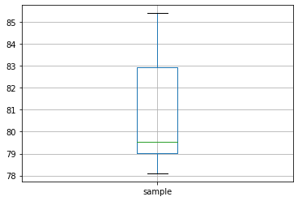

```python
# 296페이지 실습
df = pd.DataFrame({'sample': [85.0, 79.0, 79.1, 79.9, 81.6, 78.6, 85.4, 83.4, 78.1, 79.2]})
df.boxplot(['sample'])
statistic, p = stats.shapiro(df['sample'])
print("statistic={}, p-value={}".format(statistic, p))

t_result = stats.ttest_1samp(df, 78.0)
t, p = t_result.statistic.round(3), t_result.pvalue.round(3)

print("1-Sample t-test")
print("t 통계량: {}".format(t))
print("p-value: {}".format(p))
```

-> 정규성 검정 결과 p값이 0.05보다 크므로 정규성을 띤다.

# 2-Sample t-test

```
statistic=0.8425756096839905, p-value=0.08004552870988846
statistic=0.7734811902046204, p-value=0.014793740585446358
2-Sample t-test
t: 1.7
p: 0.111
```

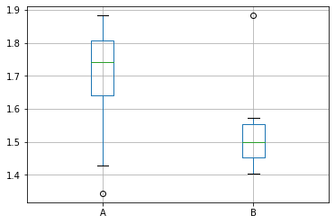

```python
# 299페이지 실습
df = pd.DataFrame({'A': [1.883, 1.715, 1.799, 1.768, 1.711, 1.832, 1.427, 1.344],
                   'B': [1.435, 1.572, 1.486, 1.511, 1.457, 1.548, 1.404, 1.883]})
df.boxplot(['A', 'B'])

statistic, p = stats.shapiro(df['A'])
print("statistic={}, p-value={}".format(statistic, p))

statistic, p = stats.shapiro(df['B'])
print("statistic={}, p-value={}".format(statistic, p))

from scipy.stats import bartlett
stats.bartlett(df['A'], df['B'])

t_result = stats.ttest_ind(df['A'], df['B'])
t, p = t_result.statistic.round(3), t_result.pvalue.round(3)

print("2-Sample t-test")
print("t: {}".format(t))
print("p: {}".format(p))
```

# Paired t-test

```python
# 302페이지 실습
df1 = pd.DataFrame({'before': [720, 589, 780, 648, 720, 589, 780, 648, 780, 648]})
df2 = pd.DataFrame({'after': [710, 580, 787, 712, 750, 600, 782, 670, 790, 680]})

t_result = stats.ttest_rel(df1, df2)
t, p = t_result.statistic.round(3), t_result.pvalue.round(4)

print("Paired t-test")
print("t: {}".format(t))
print("p: {}".format(p))
```

```
Paired t-test
t: [-2.266]
p: [0.0497]
```

-> 유의수준 5%에서 검정결과 p값이 0.0497이므로 학원 수강 전후의 점수는 차이가 있다고 할 수 있다.

# 1 Proportion test

```python
# 307페이지 실습
'''
H0: p = 0.5
H1: p != 0.5

p = 40/100 = 0.4
'''

from statsmodels.stats.proportion  import proportions_ztest

count = 40
n_obs = 100
value = 0.5

stat, pval = proportions_ztest(count, n_obs, value)

print("1 Proportion test")
print("z:{0:0.3f}".format(stat))
print("p:{0:0.3f}".format(pval))
```

```
1 Proportion test
z:-2.041
p:0.041
```

-> p 값이 0.05보다 작으므로 동전이 정상이 아니라고 할 수 있다.

# 2 Proportion test

```python
# 310페이지 실습
'''
H0: p1 = p2
H1: p1 != p2
'''

count = np.array([14, 5])
nobs = np.array([1200, 1200])

stat, pval = proportions_ztest(count, nobs)

print("2 Proportion test")
print("z:{0:0.3f}".format(stat))
print("p:{0:0.3f}".format(pval))
```

```
2 Proportion test
z:2.073
p:0.038
```

-> p값이 0.05보다 작으므로 두 공장의 불량률은 차이가 있다고 할 수 있다.

# 카이제곱 검정

```python
# 318페이지 실습

df = pd.DataFrame({'A/S': [18, 8, 4, 4, 3, 3], '가격': [1, 2, 1, 1, 1, 25], '성능': [8, 14, 3, 2, 3, 8],
                   '확장성': [7, 5, 4, 3, 1, 10], '디자인': [10, 5, 9, 2, 1, 2], '안정성': [9, 9, 5, 7, 1, 1],
                   '기능성': [10, 4, 4, 3, 1, 7]})

chi, pval, dof, expected = stats.chi2_contingency(df.T)

print("chi-square test")
print("chisq: {0:0.3f}".format(chi))
print("p: {0:0.3f}".format(pval))
print("degree pf freedom: {}".format(dof))
print("expected value: \n{}".format(expected.round(3)))
```

```
chi-square test
chisq: 98.274
p: 0.000
degree pf freedom: 30
expected value:
[[11.004  8.21   5.24   3.843  1.921  9.782]
 [ 8.528  6.362  4.061  2.978  1.489  7.581]
 [10.454  7.799  4.978  3.651  1.825  9.293]
 [ 8.253  6.157  3.93   2.882  1.441  7.336]
 [ 7.978  5.952  3.799  2.786  1.393  7.092]
 [ 8.803  6.568  4.192  3.074  1.537  7.825]
 [ 7.978  5.952  3.799  2.786  1.393  7.092]]
```

-> p값이 0.000이므로 유의수준 5%에서 각 제품에 대해 이미지에 대해 차이가 있다고 할 수 있다.

# ANOVA

```python
df = pd.read_csv("ANOVA.csv")
df.head()
```

|  | time | charge | gangjong | type |
| --- | --- | --- | --- | --- |
| 0 | 32.2 | A | a | a |
| 1 | 30.4 | B | a | a |
| 2 | 33.6 | C | a | a |
| 3 | 36.4 | D | a | a |
| 4 | 33.9 | E | a | a |

type별로 행을 구분해야 하므로 loc를 이용하여 구분해준다.

```python
df1 = df.loc[(df['type'] == 'a')]['time']
df2 = df.loc[(df['type'] == 'b')]['time']
```

```python
statistic, p = stats.shapiro(df1)
print("statistic={}, p-value={}".format(statistic, p))
statistic, p = stats.shapiro(df2)
print("statistic={}, p-value={}".format(statistic, p))
```

```
statistic=0.9821396470069885, p-value=0.9907689690589905
statistic=0.9098271131515503, p-value=0.2122616022825241
```

-> p값이 0.05보다 크므로 정규성을 띤다.

```python
stats.levene(df1, df2)

f_result = stats.f_oneway(df1, df2)

f, p = f_result.statistic.round(3), f_result.pvalue.round(3)

print("One-Way")
print("F 통계량: {}".format(f))
print("p-value: {}".format(p))
```

```
One-Way
F 통계량: 9.654
p-value: 0.005
```

-> 유의수준 5%에서 p값이 0.05보다 작으므로 그룹 간의 평균 차이가 있다고 할 수 있다.

# 상관분석

```python
df1=  [37.6, 38.6, 37.2, 36.4, 38.6, 39, 37.2, 36.1, 35.9, 37.1, 36.9, 37.5, 36.3, 38.1, 39, 36.9, 36.8, 37.6, 33, 33.5]
df2 = [14, 15, 14, 16, 17, 14, 17, 16, 15, 16, 14, 16, 18, 13, 15, 17, 14, 16, 20, 21]

corr, pval = stats.pearsonr(df1, df2)

print("Correlation Analysis")
print("corr: {0:0.3f}".format(corr))
print("p-value: {0:0.3f}".format(pval))
```

```
Correlation Analysis
corr: -0.723
p-value: 0.000
```

-> 상관계수가 -0.723이므로 초코칩의 강도와 재료 반죽온도간에 강한 음의 상관성이 있다.